# Exam 1 Summary Sheet

Phil

October 10, 2017

# Basic Matrix Operations

Define A = 2x2 matrix

```r
A <- matrix(c(1, 2, 2, -2), nrow=2)
A
```

```
##      [,1] [,2]
## [1,]    1    2
## [2,]    2   -2
```

Eigen Decomposition

```r
(ee <- eigen(A))
```

```
## eigen() decomposition
## $values
## [1]  2 -3
##
## $vectors
##            [,1]       [,2]
## [1,] -0.8944272 -0.4472136
## [2,] -0.4472136  0.8944272
```

Spectral Decomposition

```r
ee$values[1] * (ee$vectors[,1] %*% t(ee$vectors[,1])) +
  ee$values[2] * (ee$vectors[,2] %*% t(ee$vectors[,2]))
```

```
##      [,1] [,2]
## [1,]    1    2
## [2,]    2   -2
```

Determinant

```r
det(A)
```

```
## [1] -6
```

```r
ee$values[1] * ee$values[2] == det(A)
```

```
## [1] TRUE
```

Trace

```r
sum(diag(A))
```

```
## [1] -1
```

```r
ee$values[1] + ee$values[2] == sum(diag(A))
```

```
## [1] TRUE
```

We can tell that a given matrix is orthogonal if it’s columns are of unit length and mututally perpendicular.

```r
A[,1] * t(A[,2])
```

```
##      [,1] [,2]
## [1,]    2   -4
```

A matrix will only be positive definite if the eigenvalues are all positive.

```r
(ee$values[1] > 0) && (ee$values[2] > 0)
```

```
## [1] FALSE
```

Find the inverse of a given matrix.

```r
(A_inv <- solve(A))
```

```
##           [,1]       [,2]
## [1,] 0.3333333  0.3333333
## [2,] 0.3333333 -0.1666667
```

```r
eigen(A_inv)
```

```
## eigen() decomposition
## $values
## [1]  0.5000000 -0.3333333
##
## $vectors
##            [,1]       [,2]
## [1,] -0.8944272  0.4472136
## [2,] -0.4472136 -0.8944272
```

# Multivariate Normal Simulation

We will need to incorporate the MASS library and set up our preliminaries.

```r
library(MASS)
mu <- c(1, 0)
p <- length(mu)
n <- 100
S <- matrix(c(1, -0.8, -0.8, 1), nrow=2)
```

Now, we can generate some random data.

```r
rand_out <- MASS::mvrnorm(n=n, mu=mu, Sigma=S)

(x_bar_obs <- colMeans(rand_out))
```

```
## [1]  1.05861550 -0.04170229
```

```r
(S_obs <- var(rand_out))
```

```
##            [,1]       [,2]
## [1,]  0.7281853 -0.4557849
## [2,] -0.4557849  0.6938874
```

As these are bivariate data, it can be helpful to plot them in an ellipse.

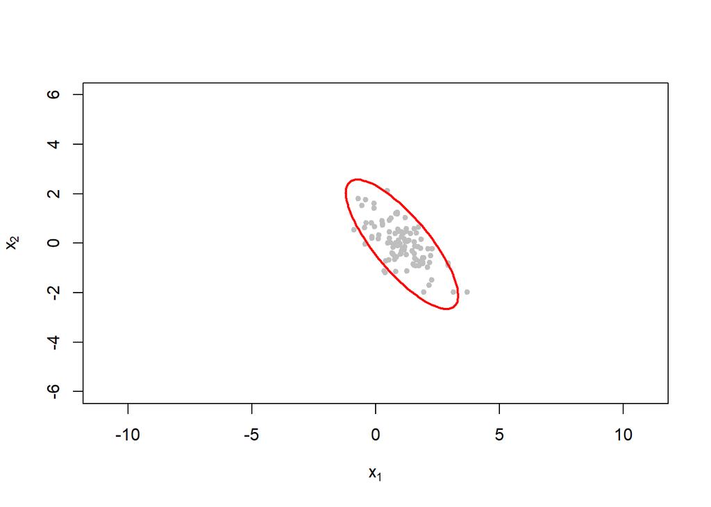

```r
library("plotrix")
c2 <- qchisq(1 - 0.05, p)

rho_1 <- S_obs[1, 2] / (sqrt(S_obs[1, 1]) * sqrt(S_obs[2, 2]))
theta_1 <- acos(rho_1)

lambda_obs <- eigen(S)$values

plot(rand_out, xlim = c(-6, 6), ylim = c(-6, 6), xlab = expression(x[1]),
  ylab = expression(x[2]), pch = 20, col = "grey", asp = 1)

draw.ellipse(x_bar_obs[1], x_bar_obs[2], sqrt(c2 * lambda_obs[1]), sqrt(c2 * lambda_obs[2]),
  angle = theta_1 * 57.2957795, deg = TRUE, border = "red", lwd = 2)
```

```r
p <- ncol(S_obs)
n <- nrow(rand_out)
ee_obs <- eigen(S_obs)

ee_obs$vector
```

```
##            [,1]       [,2]
## [1,] -0.7202772 -0.6936864
## [2,]  0.6936864 -0.7202772
```

```r
sqrt(ee_obs$values) * sqrt( (p * (n - p)) / (n * (n - p)) * qf(1-0.05,p, n-p )  )
```

```
## [1] 0.2685347 0.1255012
```

# Simultaneous Confidence Intervals

### T_squared based simultaneous intervals

```r
c2 <- (((n - 1) * p) / (n - p)) * qf(0.95, p, n - p)
x_bar_obs
```

```
## [1]  1.05861550 -0.04170229
```

```r
x_bar_obs[1] + c(-1, 1) * sqrt(c2 * S_obs[1,1] / n)
```

```
## [1] 0.845427 1.271804
```

```r
x_bar_obs[2] + c(-1, 1) * sqrt(c2 * S_obs[2,2] / n)
```

```
## [1] -0.2498096  0.1664050
```

### Bonferroni simultaneous intervals

```r
x_bar_obs
```

```
## [1]  1.05861550 -0.04170229
```

```r
x_bar_obs[1] + c(-1, 1) * qt(1 - 0.05 / (2 * p), n - 1) * sqrt(S[1,1] / n)
```

```
## [1] 0.8310151 1.2862158
```

```r
x_bar_obs[2] + c(-1, 1) * qt(1 - 0.05 / (2 * p), n - 1) * sqrt(S[2,2] / n)
```

```
## [1] -0.2693026  0.1858981
```

# T-squared inference

We can see from the confidence intervals obtained that the simulated base parameters are inside of the intervals. We can conduct an equivalent hypothesis test.

```r
mu_0 <- c(1,0)
# Test Statistic
(T2_obs <- n * t(x_bar_obs - mu_0) %*% solve(S_obs) %*% (x_bar_obs - mu_0))
```

```
##           [,1]
## [1,] 0.4779793
```

```r
# critical value
c2
```

```
## [1] 6.241451
```

```r
# p-value
1 - pf( (n - p) / ((n - 1) * p) * T2_obs , p, n-p )
```

```
##           [,1]
## [1,] 0.7897757
```

# Bootstrapping

```r
B <- 1000
set.seed(1738)

rand_out_scale <- scale(rand_out, center=T, scale=F)
T2_output <- numeric(B)

for(i in 1:B){
  temp <- rand_out_scale[sample(1:n, replace=T), ]
  x_bar_temp <- colMeans(temp)
  S_temp <- var(temp)
  T2_b <- drop(n * t(x_bar_temp - mu_0) %*% solve(S_temp) %*% (x_bar_temp - mu_0))
  T2_output[i] <- T2_b
}
```

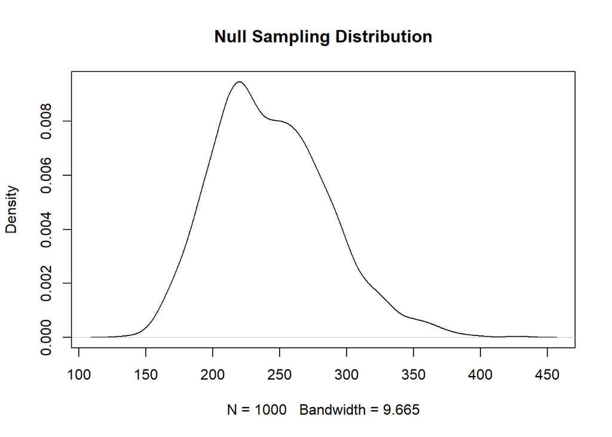

```r
plot(density(T2_output), main="Null Sampling Distribution")
abline(v=drop(T2_obs), col="blue")
```

```r
sum(T2_output >= drop(T2_obs)) / B
```

```
## [1] 1
```